# Lecture 16b:ANCOVA in tidyverse

19 October 2021

This is the `tidyverse` version of “L16 linear regression with two lines (ANCOVA)”.

In this example we fit a linear model with normal errors to some data comprising a linear covariate and a categorical explanatory variable with two levels. This is commonly referred to as ANCOVA (ANalysis of COVAriance) but we prefer to simply class it as one of the foundation models in the class of Generalised Linear Models. We will fit these models using the function `glm()` but you could fit it with `lm()` or `aov()` intstead, in which case you will be given slightly different output. However, one important point to note is that if you use `aov()`, then in this example, the order in which you specify the explanatory variables will produce very different estimates of significance arising from the fact that the data are not balanced and orthogonal, and that `aov()` fits using sequential sums of squared rather than marginal sums of squared.

#ANCOVA - Analysis of covariance has one continous response variable and at least one continous and categorical explanatory vairable.

EXAMPLE: Data file - Grazing.csv Variables: Root-continous, Seed-continous and Grazing-categorical Question: Which one of the continuos variables is explanatory and which one is response? Research question: Does diameter of the top of its rootstock influences weight of the seed produced in grazed or ungrazed plants? Solution: Diameter of the top of rootstock (Root) - explanatory variable (x-axis) Weight of the seed produced - response variable (y-axis)

There are in theory 6 posible models that might explain these data: 1. Both slopes and intercept are different (two distinct non-parallel lines) 2. Different intercepts and same slope (two parallel) 3. Same intercept different slopes (this would be an unusual model to fit, unless we were very confident that the intercepts were the same. By way of example, this can arise if you are sure that the data and the underlying lines describing them are constrained to converge at the origin $(x=0, y=0)$). 4. No slope and different intercepts (this is essentially a t-test comparing the means between the two groups) 5. One slope and one intercept (a simple linear regression) 6. No slope only one intercept (this is basically the null model, and comprises a single mean and error term to describe the data).

# 1 Housekeeping

Remember that `rm(list=ls())` is not sufficient for a full clean set up of R, and you should use `Ctrl/Cmd-SHIFT-F10` in Rstudio to Restart R cleanly and check that this works at least at the end of your analysis, or periodically during development.

```r
# remove (almost) all objects currently held in the R environment
rm(list=ls())
```

## 1.1 Set up

Install required packages.

```r
library(tidyverse) # load the tidyverse suite of packages
library(magrittr)  # for the %<>% piping construct
library(broom)     # for plotting actual model objects
```

# 2 Read in your data

Enter or read in your data from a file as a CSV (comma separated) file from Excel

REMEMBER: Choose your working directory and put file inside that directory!

# 3 EXPLORE DATA

```r
head(mydata) # Return the First Part of an Object -usually first six observations
```

|  | Root | Seed | Grazing |
| --- | --- | --- | --- |
| 1 | 6.225 | 59.77 | Ungrazed |
| 2 | 6.487 | 60.98 | Ungrazed |
| 3 | 4.919 | 14.73 | Ungrazed |
| 4 | 5.130 | 19.28 | Ungrazed |
| 5 | 5.417 | 34.25 | Ungrazed |
| 6 | 5.359 | 35.53 | Ungrazed |

```r
head(mydata, n = 12L) # option - name of the Object, n= number of lines you want to see (12) from the start of the Object
```

|  | Root | Seed | Grazing |
| --- | --- | --- | --- |
| 1 | 6.225 | 59.77 | Ungrazed |
| 2 | 6.487 | 60.98 | Ungrazed |
| 3 | 4.919 | 14.73 | Ungrazed |
| 4 | 5.130 | 19.28 | Ungrazed |
| 5 | 5.417 | 34.25 | Ungrazed |
| 6 | 5.359 | 35.53 | Ungrazed |
| 7 | 7.614 | 87.73 | Ungrazed |
| 8 | 6.352 | 63.21 | Ungrazed |
| 9 | 4.975 | 24.25 | Ungrazed |
| 10 | 6.930 | 64.34 | Ungrazed |

[output cut: 2 more lines]

```r
# check the structure of the data
str(mydata) # Return complete Object
```

```
'data.frame':   40 obs. of  3 variables:
 $ Root   : num  6.22 6.49 4.92 5.13 5.42 ...
 $ Seed   : num  59.8 61 14.7 19.3 34.2 ...
 $ Grazing: chr  "Ungrazed" "Ungrazed" "Ungrazed" "Ungrazed" ...
```

We expect the response variable Seed and the linear covariate Root to both be numerical, but Grazing represents two categories in this experiment and we should convert these to a factor: the factor format is interpreted by various functions including plotting functions and makes life easier (although many functions will internally coerce a character to factor, it is better to do this ourselves). Since the experimental treatment is designed to look at the effect of Grazing over no grazing, I am going to force the baseline level in this factor to be the “Ungrazed” category. This means that our fitted model later on will expclitly tell us what the effect of grazing is, rather than what the effect of “ungrazing” is which is a bit counter-intuitive. **By default, R will specify the order of the levels alphabetically.**

```r
# coerce to factor and specify the order of the levels
mydata %<>% mutate(Grazing = factor(Grazing, levels = c("Ungrazed", "Grazed")))


# check that this came out as expected.
# str(mydata)


# if you want you can just pull out the levels only
#levels(mydata)
```

# 4 Visualise our data with a scatterplot

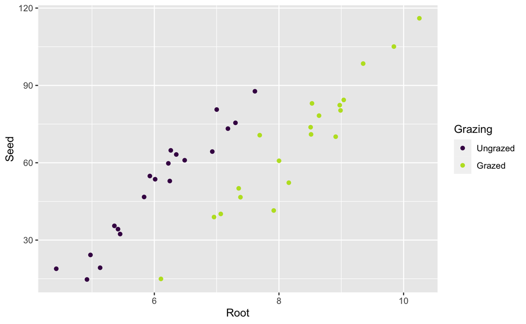

```r
g1 <- ggplot(data = mydata,
             mapping = aes(x = Root, y = Seed, color = Grazing)) +
  geom_point() +
  scale_color_viridis_d(end = 0.9)


print(g1)
```

# 5 Fit the most complicated model (non-parallel lines)

Our *a priori* assumption here is that both slopes and intercept in Grazed and Ungrazed group differ! This means that we need to estimate a total of 4 coefficients. Specifically, we fit a model of the form:

$$\text{Seed} = (\beta_0 + \beta_{Grazed}) + (\beta_1 + \beta_{2:Grazed})\text{Root}$$

where $\beta_{Grazed} and \beta_{2:Grazed}$ are only included for data for which `Grazing == Grazed` and are otherwise $0$, in which case the equation simplifies to

$$\text{Seed} = \beta_0 + \beta_1\text{Root}$$
and represents the line for the **Ungrazed** plants.

**Important:** when fitting models such as this where the slopes differ between two or more categories, it is generally the case that we are left unable to make any meaningful statement about the significance and magnitude of the different between the two intercepts. This occurs because there is no longer a fixed effect of Grazing in this example along the gradient of Root diameter, since non-parallel lines cross at some point, and are infinitely apart (both positively and negatively) at positive and negative infinity. One thing we can do when fitting linear models such as this is to recentre the data by adding or substracting an amount to the explanatory variables. This has the effect of changing the location of the intercepts, but does not affect the estimates of the slopes: meaning that we could end up with differences between the intercepts of the two lines that are either exactly zero, or massively positive or negative depending on our choice. As ever, there are exceptions to this rule, and maybe we want to know if there was a difference between the intercepts at the start of a time-series experiment between two groups, and in that case being able to test the differences betweent he intercepts at a particular value of the explanatory variable might be informative. In the case of this Seed production example though, there is no such obvious insight to be gained.

Specify the interaction in the GLM model

```r
# fit the glm and store the ouput in a new object "model1"
model1 <- glm( Seed ~ Root + Grazing + Root:Grazing,
               data = mydata )

# note that the above line is the full syntax for the short
# version. Note the "*" to denote, "include all interactions"
model1 <- glm( Seed ~ Root * Grazing,
               data = mydata )


summary(model1)
```

```
Call:
glm(formula = Seed ~ Root * Grazing, data = mydata)

Deviance Residuals:
     Min        1Q    Median        3Q       Max
-17.3177   -2.8320    0.1247    3.8511   17.1313

Coefficients:
                   Estimate Std. Error t value Pr(>|t|)
(Intercept)         -94.367     10.933  -8.632 2.71e-10 ***
Root                 23.996      1.788  13.417 1.41e-15 ***
GrazingGrazed       -30.806     16.842  -1.829   0.0757 .
Root:GrazingGrazed   -0.756      2.354  -0.321   0.7500
---
Signif. codes:  0 ‘***’ 0.001 ‘**’ 0.01 ‘*’ 0.05 ‘.’ 0.1 ‘ ’ 1

(Dispersion parameter for gaussian family taken to be 46.65692)

    Null deviance: 23743.8  on 39  degrees of freedom
Residual deviance:  1679.6  on 36  degrees of freedom
AIC: 273.01

Number of Fisher Scoring iterations: 2
```

Note that here we have specified the main effects of both `Root` and `Grazing` and manually specified the interaction between the two using the “:”” notation `Root:Grazing`. The short-hand version `glm(See ~ Root * Grazing)` with the “*” notation automatically fits all main and interection effects. This short-hand is fine when we are doing a relatively straight forward model with a few explanatory variables and only simple interactions between pairs of variables, but this can quickly get out of hand with more variables and 3, 4 or even more way interaction terms. Generally it is better, or at least clearer, to specify exactly what you want manually so there are no surprises.

When we analyse coefficients we see that there is no evidence for a significant interaction between Root and Grazing which is the coefficient that determines whether there is a difference between the two slopes. The next step might be to specify a more simple model with parallel lines, that differ not in their slopes, but only in their intercepts.

## 5.1 Plotting the fitted model over the data

One of the things about ggplot is that is it encourages short cuts. While making your life potentially easy, it doesnt lend itself to good error checking. For example, one can very easily let ggplot fit separate models to the data.

The approach below effectively splits the data in to two entirely separate pieces based on the Grazing variable which we have used to assign different colours in the plot and fits two linear models with two error terms $\epsilon_{Grazed}$ and $\epsilon_{Ungrazed}$. This is different to our call to the `glm()` function which does something similar but ties the two groups of data together by calculating a single error term $\epsilon$.

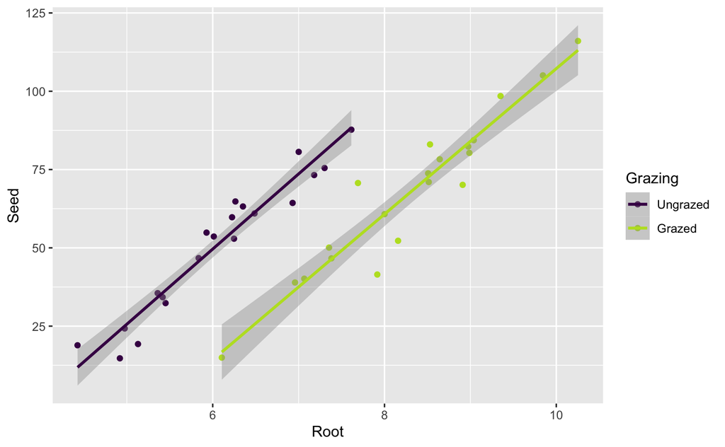

```r
# generate a new figure from our basic scatter plot g1 and let
# geom_smooth() add lines based on the colour grouping
g_2 <- g1 + geom_smooth(method = "lm")

print(g_2)
```

In order to plot the actual models we fitted, we have to actually make reference to our model in the ggplot construct. We do this using some helper functions in the `broom` package which will generate a new `data.frame` object (strictly a `tibble` per the tidyverse realm) based on the data we have and the model fit we created, keep it all in the same structure as the original data and hence allow ggplot to inherit all the information it needs to add it to the plot.

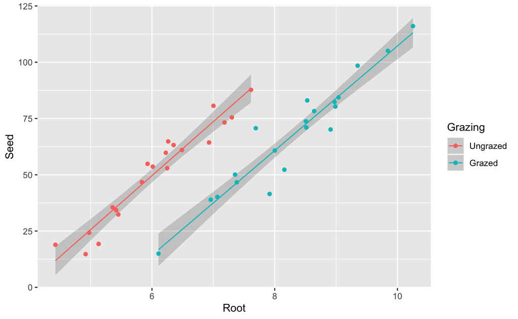

```r
model1_fitted <- model1 %>% augment(se_fit = TRUE)

g_model1 <- ggplot(data = model1_fitted,
                   mapping = aes(x = Root, y = Seed,
                                 color = Grazing)) +
  geom_ribbon(aes(ymin=.fitted-1.96*.se.fit, ymax=.fitted+1.96*.se.fit),
              alpha=0.2, linetype = 0) +
  geom_point() +
  geom_line(aes(Root, .fitted))

print(g_model1)
```